# Cyclistic compartilhamento de bicicletas em Chicago

Milton Takeshi

2025-05-12

## Introdução

Este estudo investigou os padrões de uso do serviço de compartilhamento de bicicletas Cyclistic em Chicago, com o objetivo de identificar diferenças significativas entre membros anuais e ciclistas casuais. A análise se baseou em dados de viagens de bicicleta de maio de 2024 a abril de 2025, explorando dimensões como tempo de viagem, frequência de uso por dia da semana, tipo de bicicleta preferida e distribuição geográfica. O objetivo final é fornecer recomendações acionáveis para a Cyclistic, visando aumentar a receita através da atração de novos membros ou da conversão de ciclistas casuais.

## Metodologia

Os dados foram previamente processados e integrados em um único arquivo (Completo-divvy-tripdata.csv). A análise exploratória envolveu a criação de novas variáveis, como a duração da viagem (ride_time) e o dia da semana (day_of_week). Foram realizadas etapas de limpeza para tratar valores ausentes e outliers relevantes. A visualização de dados, através de gráficos de barras, permitiu comparar os padrões de uso entre os grupos de usuários em diferentes dimensões. A análise geográfica inicial focou na identificação de áreas de maior concentração de cada tipo de usuário.

```r
QCOMPLETA <- read.csv(
  file = "c:/Temp/Completo-divvy-tripdata.csv"
)
```

## Criação de novas colunas para posterior análise dos dados

Foi criado duas colunas novas, sendo: a primeira o cálculo da duração de cada viagem (subtraindo a coluna ended_at menos a coluna started_at); e a segunda coluna criada foi o dia da semana que a viagem começou;

```r
# Foi criado duas colunas novas, sendo: a primeira o cálculo da duração de cada viagem, subtraindo a coluna ended_at menos a started_at
# A segunda calcula o dia da semana que cada viagem começou
QCOMPLETA <- QCOMPLETA %>%
  mutate(ride_time = as.numeric(difftime(strptime(ended_at,"%Y-%m-%d %H:%M:%S"),strptime(started_at,"%Y-%m-%d %H:%M:%S"),units = "mins")))

# Realiza a extração do dia da semana que cada viagem começou
QCOMPLETA <- QCOMPLETA %>%
  mutate(day_of_week = weekdays(strptime(started_at,"%Y-%m-%d %H:%M:%S"))) %>%
  glimpse()
```

```
## Rows: 5,735,884
## Columns: 15
## $ ride_id            <chr> "7D9F0CE9EC2A1297", "02EC47687411416F", "101370FB2D…
## $ rideable_type      <chr> "classic_bike", "classic_bike", "classic_bike", "el…
## $ started_at         <chr> "2024-05-25 15:52:42", "2024-05-14 15:11:51", "2024…
## $ ended_at           <chr> "2024-05-25 16:11:50", "2024-05-14 15:22:00", "2024…
## $ start_station_name <chr> "Streeter Dr & Grand Ave", "Sheridan Rd & Greenleaf…
## $ start_station_id   <chr> "13022", "KA1504000159", "13022", "13022", "KA15040…
## $ end_station_name   <chr> "Clark St & Elm St", "Sheridan Rd & Loyola Ave", "W…
## $ end_station_id     <chr> "TA1307000039", "RP-009", "TA1309000010", "TA130700…
## $ start_lat          <dbl> 41.89228, 42.01059, 41.89228, 41.89227, 41.90349, 4…
## $ start_lng          <dbl> -87.61204, -87.66241, -87.61204, -87.61195, -87.643…
## $ end_lat            <dbl> 41.90297, 42.00104, 41.87077, 41.93625, 41.90297, 4…
## $ end_lng            <dbl> -87.63128, -87.66120, -87.62573, -87.65266, -87.631…
## $ member_casual      <chr> "casual", "casual", "member", "member", "casual", "…
## $ ride_time          <dbl> 19.1333333, 10.1500000, 23.2000000, 18.6333333, 6.7…
## $ day_of_week        <chr> "sábado", "terça-feira", "quinta-feira", "sexta-fei…
```

```r
# Efetuar uma análise mais detalhada tempo médio
tot <- QCOMPLETA %>%
  group_by(member_casual,day_of_week) %>%
  summarize(count = n(), ride_time = mean(ride_time))
tot
```

```
## # A tibble: 15 × 4
## # Groups:   member_casual [3]
##    member_casual day_of_week    count ride_time
##    <chr>         <chr>          <int>     <dbl>
##  1 ""            <NA>          371341      NA
##  2 "casual"      domingo       336889      28.8
##  3 "casual"      quarta-feira  253145      22.0
##  4 "casual"      quinta-feira  250226      21.7
##  5 "casual"      segunda-feira 230464      23.4
##  6 "casual"      sexta-feira   309798      24.3
##  7 "casual"      sábado        414789      27.7
##  8 "casual"      terça-feira   208140      20.8
##  9 "member"      domingo       376972      14.0
## 10 "member"      quarta-feira  551288      12.1
## 11 "member"      quinta-feira  518641      12.1
## 12 "member"      segunda-feira 477615      11.9
## 13 "member"      sexta-feira   496456      12.4
## 14 "member"      sábado        440836      13.8
## 15 "member"      terça-feira   499284      11.9
```

## Realização da limpeza dos valores ausentes

```r
# Realiza a limpeza dos valores que ausentes (NA)
QCOMPLFIL <- QCOMPLETA[!is.na(QCOMPLETA$ride_time), ]

summary(QCOMPLFIL)
```

```
##    ride_id          rideable_type       started_at          ended_at
##  Length:5364543     Length:5364543     Length:5364543     Length:5364543
##  Class :character   Class :character   Class :character   Class :character
##  Mode  :character   Mode  :character   Mode  :character   Mode  :character
##
##
##
##
##  start_station_name start_station_id   end_station_name   end_station_id
##  Length:5364543     Length:5364543     Length:5364543     Length:5364543
##  Class :character   Class :character   Class :character   Class :character
##  Mode  :character   Mode  :character   Mode  :character   Mode  :character
##
##
##
##
##    start_lat       start_lng         end_lat         end_lng
##  Min.   :41.64   Min.   :-87.91   Min.   :16.06   Min.   :-144.05
##  1st Qu.:41.88   1st Qu.:-87.66   1st Qu.:41.88   1st Qu.: -87.66
##  Median :41.90   Median :-87.64   Median :41.90   Median : -87.64
##  Mean   :41.90   Mean   :-87.65   Mean   :41.90   Mean   : -87.65
##  3rd Qu.:41.93   3rd Qu.:-87.63   3rd Qu.:41.93   3rd Qu.: -87.63
##  Max.   :42.07   Max.   :-87.52   Max.   :87.96   Max.   : 152.53
##                                   NA's   :6110    NA's   :6110
##  member_casual        ride_time         day_of_week
##  Length:5364543     Min.   :-2748.317   Length:5364543
##  Class :character   1st Qu.:    5.533   Class :character
##  Mode  :character   Median :    9.700   Mode  :character
##                     Mean   :   17.067
##                     3rd Qu.:   17.200
##                     Max.   : 1559.917
##
```

## Resultados

A análise revelou diferenças notáveis entre membros anuais e ciclistas casuais:

Frequência e Duração das Viagens: Membros tendem a realizar viagens mais frequentes, mas com menor duração média, especialmente durante os dias da semana. Ciclistas casuais, por outro lado, utilizam o serviço com maior intensidade nos finais de semana e por períodos mais longos.

```r
tot_drop <- QCOMPLFIL %>%
  # filter(!is.na(ride_time)) %>%
  # filter(!is.na(day_of_week)) %>%
  filter(ride_time > 0) %>%
  #filter(ride_time < 6000) %>%
  group_by(member_casual, day_of_week) %>%
  summarize(count = n(), ride_time = mean(ride_time), .groups = "drop")


# Sempre classifique por dia da semana para tornar o gráfico legível
tot_drop$day_of_week <- factor(tot_drop$day_of_week, levels= c("domingo", "segunda-feira", "terça-feira", "quarta-feira", "quinta-feira", "sexta-feira", "sábado"))
tot_drop <- tot_drop[order(tot_drop$day_of_week), ]
tot_drop
```

```
## # A tibble: 14 × 4
##    member_casual day_of_week    count ride_time
##    <chr>         <fct>          <int>     <dbl>
##  1 casual        domingo       336854      28.8
##  2 member        domingo       376944      14.0
##  3 casual        segunda-feira 230451      23.4
##  4 member        segunda-feira 477604      11.9
##  5 casual        terça-feira   208136      20.8
##  6 member        terça-feira   499265      11.9
##  7 casual        quarta-feira  253127      22.0
##  8 member        quarta-feira  551258      12.1
##  9 casual        quinta-feira  250217      21.7
## 10 member        quinta-feira  518608      12.1
## 11 casual        sexta-feira   309784      24.3
## 12 member        sexta-feira   496423      12.4
## 13 casual        sábado        414756      27.7
## 14 member        sábado        440812      13.8
```

```r
library(scales) # Carregue o pacote scales
```

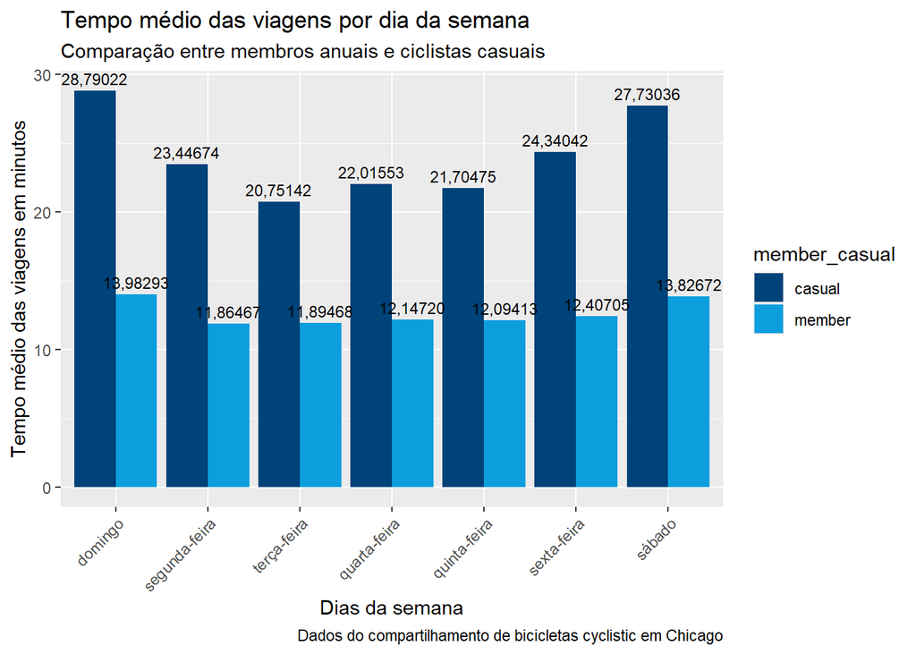

```r
# Monta o gráfico de barras com tempo das viagens por dia da semana
ggplot(data = tot_drop) +
  geom_col(mapping = aes(x = day_of_week, y = ride_time, fill = member_casual, group = member_casual), position = position_dodge()) +
  geom_text(aes(x = day_of_week, y = ride_time, label = format(ride_time, big.mark = ".", decimal.mark = ",", scientific = FALSE), group = member_casual),
            position = position_dodge(width = 0.9),
            vjust = -0.5,
            size = 3) +
  theme(axis.text.x = element_text(angle = 45, hjust = 1)) +
  scale_fill_manual(values = c("#00437A", "#0D9EDE")) +
  scale_y_continuous(labels = function(x) format(x, big.mark = ".", decimal.mark = ",", scientific = FALSE)) +
  labs(title = "Tempo médio das viagens por dia da semana",
       subtitle = "Comparação entre membros anuais e ciclistas casuais",
       caption = "Dados do compartilhamento de bicicletas cyclistic em Chicago",
       x = "Dias da semana",
       y = "Tempo médio das viagens em minutos")
```

O gráfico acima ilustra claramente a diferença no tempo médio de viagem entre os dois grupos ao longo da semana, com ciclistas casuais apresentando tempos significativamente maiores, especialmente nos finais de semana.

O gráfico abaixo destaca a maior frequência de uso por parte dos membros durante a semana, enquanto os ciclistas casuais concentram suas viagens nos finais de semana.

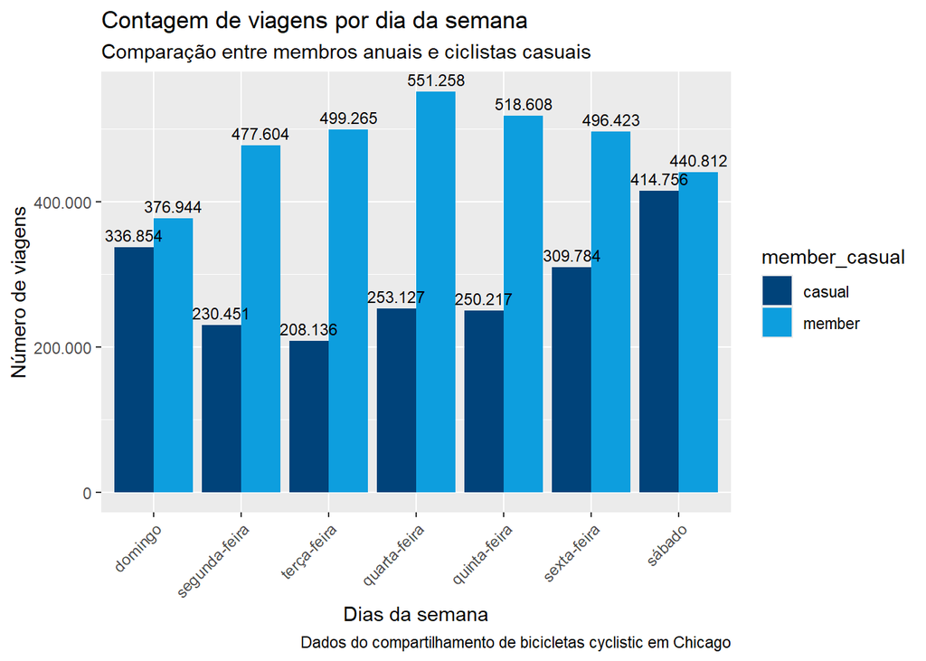

```r
# Monta o gráfico de barras com as contagems de viagens por dia da semana
ggplot(data = tot_drop) +
  geom_col(mapping = aes(x = day_of_week, y = count, fill = member_casual, group = member_casual), position = position_dodge()) +
  geom_text(aes(x = day_of_week, y = count, label = format(count, big.mark = ".", decimal.mark = ",", scientific = FALSE), group = member_casual),
            position = position_dodge(width = 0.9),
            vjust = -0.5,
            size = 3) +
  theme(axis.text.x = element_text(angle = 45, hjust = 1)) +
  scale_fill_manual(values = c("#00437A", "#0D9EDE")) +
  scale_y_continuous(labels = function(x) format(x, big.mark = ".", decimal.mark = ",", scientific = FALSE)) +
  labs(title = "Contagem de viagens por dia da semana",
       subtitle = "Comparação entre membros anuais e ciclistas casuais",
       caption = "Dados do compartilhamento de bicicletas cyclistic em Chicago",
       x = "Dias da semana",
       y = "Número de viagens")
```

O próximo fator a ser analisado é o tipo de bicicleta preferido.

[figure not shown]

```r
# O próximo fator a ser analisado é o tipo de bicicleta preferido.
ggplot(data=QCOMPLFIL) +
  geom_bar(mapping=aes(x=rideable_type, fill = rideable_type)) +
  facet_wrap(~member_casual) +
  labs(title="Total tempo médio para cada tipo de bicicletas",
       caption = "Dados do compartilhamento de bicicletas cyclistic em Chicago",
       x = "Tipos de bicicletas",
       y = "Tempo médio")
```

A preferência por bicicletas elétricas é evidente em ambos os grupos, conforme mostrado no gráfico acima.

## Dados referente localização geográfica

Resumo dos dados agrupado por nome da estação e dividida em tabelas “casuais” e “membros”.

```r
stations <- QCOMPLFIL %>%
  filter(start_station_name != "") %>%
  filter(end_station_name != "") %>%
  subset(select = -c(rideable_type,started_at,ended_at,start_station_id,end_station_id,ride_time,day_of_week)) %>%
  # Remove a columas que não precisa
  glimpse()
```

```
## Rows: 3,802,338
## Columns: 8
## $ ride_id            <chr> "7D9F0CE9EC2A1297", "02EC47687411416F", "101370FB2D…
## $ start_station_name <chr> "Streeter Dr & Grand Ave", "Sheridan Rd & Greenleaf…
## $ end_station_name   <chr> "Clark St & Elm St", "Sheridan Rd & Loyola Ave", "W…
## $ start_lat          <dbl> 41.89228, 42.01059, 41.89228, 41.89227, 41.90349, 4…
## $ start_lng          <dbl> -87.61204, -87.66241, -87.61204, -87.61195, -87.643…
## $ end_lat            <dbl> 41.90297, 42.00104, 41.87077, 41.93625, 41.90297, 4…
## $ end_lng            <dbl> -87.63128, -87.66120, -87.62573, -87.65266, -87.631…
## $ member_casual      <chr> "casual", "casual", "member", "member", "casual", "…
```

```r
member_stations <- stations %>%
  filter(member_casual == "member") %>%
  group_by(start_station_name) %>%
  summarize(n = n(), starting_lat = mean(start_lat), starting_lng = mean(start_lng)) %>%
  glimpse()
```

```
## Rows: 1,822
## Columns: 4
## $ start_station_name <chr> "2112 W Peterson Ave", "21st St & Pulaski Rd", "63r…
## $ n                  <int> 372, 39, 401, 7406, 2, 9467, 5734, 6556, 2, 3, 4673…
## $ starting_lat       <dbl> 41.99118, 41.85344, 41.78091, 41.87476, 41.70704, 4…
## $ starting_lng       <dbl> -87.68360, -87.72478, -87.57632, -87.64981, -87.650…
```

```r
casual_stations <- stations %>%
  filter(member_casual == "casual") %>%
  group_by(start_station_name) %>%
  summarize(n = n(), starting_lat = mean(start_lat), starting_lng = mean(start_lng)) %>%
  glimpse()
```

```
## Rows: 1,569
## Columns: 4
## $ start_station_name <chr> "2112 W Peterson Ave", "21st St & Pulaski Rd", "63r…
## $ n                  <int> 170, 51, 701, 3065, 2, 4063, 2057, 3386, 3, 6, 1995…
## $ starting_lat       <dbl> 41.99117, 41.85344, 41.78092, 41.87475, 41.70704, 4…
## $ starting_lng       <dbl> -87.68360, -87.72471, -87.57632, -87.64981, -87.650…
```

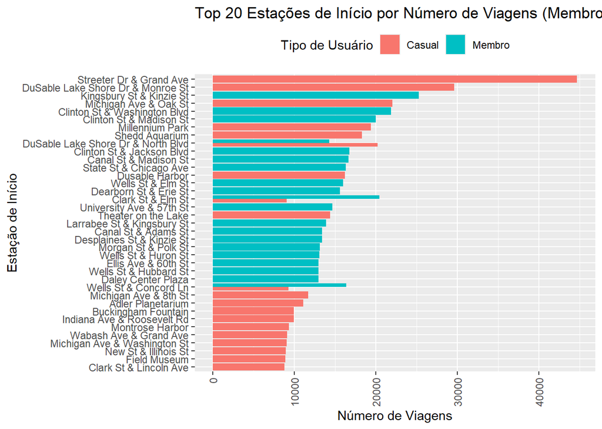

```r
# Obter os top 20 para membros
top_20_member <- member_stations %>%
  arrange(desc(n)) %>%
  head(20) %>%
  mutate(user_type = "Membro")

# Obter os top 20 para casuais
top_20_casual <- casual_stations %>%
  arrange(desc(n)) %>%
  head(20) %>%
  mutate(user_type = "Casual")

# Combinar os dois dataframes de top 20
top_20_combined <- bind_rows(top_20_member, top_20_casual)

# Criar o gráfico de barras
ggplot(top_20_combined, aes(x = reorder(start_station_name, n), y = n, fill = user_type)) +
  geom_bar(stat = "identity", position = "dodge") +
  labs(
    x = "Estação de Início",
    y = "Número de Viagens",
    fill = "Tipo de Usuário",
    title = "Top 20 Estações de Início por Número de Viagens (Membros vs. Casuais)"
  ) +
  theme(
    axis.text.x = element_text(angle = 90, hjust = 1, vjust = 0.5),
    legend.position = "top"
  ) +
  coord_flip()
```

## Recomendações

Com base na análise dos dados, as seguintes recomendações são propostas para a Cyclistic:

Incentivar a conversão de ciclistas casuais em membros através de ofertas direcionadas para uso nos finais de semana e viagens mais longas: Desenvolver campanhas de marketing que ofereçam benefícios para a adesão de planos anuais, especialmente para usuários casuais que concentram seu uso nos finais de semana e realizam viagens de maior duração. Isso pode incluir descontos em planos anuais para usuários frequentes de fim de semana ou programas de fidelidade que recompensem a conversão.

Otimizar a distribuição de bicicletas elétricas em áreas de alta demanda por ciclistas casuais: Realocar uma maior proporção de bicicletas elétricas para estações localizadas em áreas com alta concentração de ciclistas casuais, como a região próxima ao cais, especialmente durante os finais de semana. O monitoramento em tempo real da disponibilidade e uso desses veículos pode otimizar ainda mais a alocação.

Para aprofundar a análise e refinar ainda mais as recomendações, sugere-se a incorporação de dados adicionais, como informações demográficas dos usuários (anonimizadas), dados climáticos, informações sobre eventos na cidade e dados de rotas mais populares. A coleta de feedback direto dos usuários através de pesquisas também seria valiosa para entender suas necessidades e preferências em maior detalhe.

## Conclusão

A análise dos padrões de uso das bicicletas compartilhadas da Cyclistic revela diferenças claras entre membros anuais e ciclistas casuais. As recomendações apresentadas visam capitalizar esses insights para aumentar a receita, focando na conversão de usuários casuais e na otimização da oferta de bicicletas de acordo com a demanda de cada grupo. A implementação dessas recomendações, juntamente com a exploração de dados adicionais, pode contribuir significativamente para o crescimento e a sustentabilidade do serviço Cyclistic.